# Summarizing.Metric

Alene Onion

October 15, 2018

## Calculation

We will be using naive Bayes: the assumption of conditioanl independence (even when we know the data aren’t conditionally independent)

The formula for this calculation is:

P((bap>=7.5)|WAVE families in the sample) =

(P(bap>=7.5)P(Family_1|(bap>=7.5))P(Family_2|(bap>=7.5))…etc)  
/  
(P(bap>=7.5)P(Family_1|(bap>=7.5))…etc + P(5<bap<7.5)P(Family_1|(5<bap<7.5))…etc + P(bap<5)P(Family_1|(bap<5))…etc)

## Pulling Raw Data

Data used for this project includes all SBU samples collected since 1990 and reformatted so it meets these criteria:  
- Only 1 sample per site  
- Only the most recent assessment  
- Only kick sampling method  
- only collected between July and September

Read Species, Sites, and Metrics tables which were copied from the SBU database on 10/15/2018

Restrict to multiplate/kick samples, collected in sampling period, and only one result per site

## Most Least Wanted Distribution Graph

This script takes a file of all SBU kick samples since 1990 and identifies the number of WAVE Least Wanteds and WAVE Most Wanteds in each sample

It then plots all the BAP scores as well as those with more than 5,6,7,8,9,and10 most wanteds as well as those with more than 3,4,and 5 Least Wanteds

This portion of the script uses the SBU file produced by the previous script to produce a file with “sample_id”,“coll_date”,“bap”,“WAVE” where “WAVE” is the name of the WAVE bug, most or least wanted

It then distills this to a count of the number of Most or Least Wanted WAVE bugs per sample using library(plyr)

Produce one file with all the sites, the least count, and the most count and plot these data

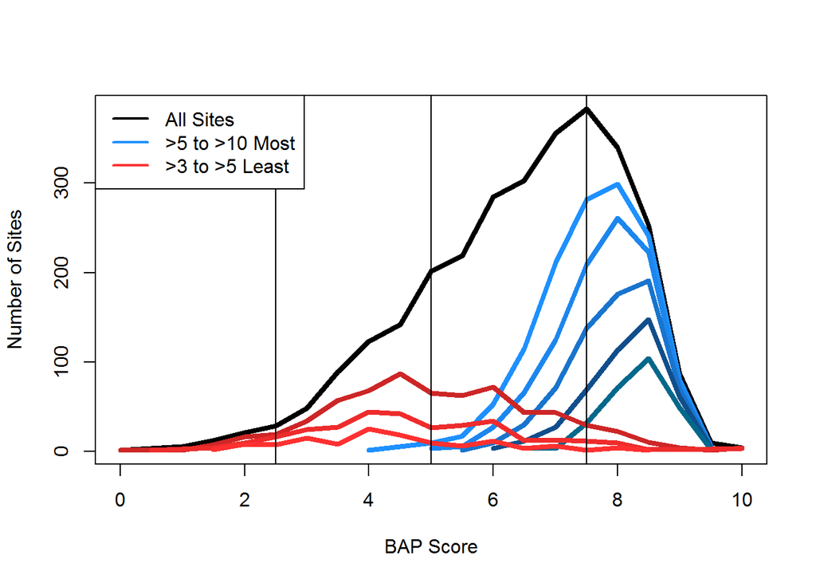

### Summary Table

PN The % of all the nonimpacted samples with a probability > the Cutoff  
EN The % of all the impaired or slight samples inaccurately identified as nonimpacted by this method  
ENI The % of all the impaired samples (allowing errors in slight) inaccurately identified as nonimpacted  
PI The % of all the impaired samples captured with a probability > the Cutoff  
EI The % of samples identified as impaired that are actually nonimpacted or slight  
CutOff The sample is restricted to only records with most or least wanteds of this value

| CutOff | Most Wanteds PN | Most Wanteds EN | Most Wanteds ENI | Least Wanteds PI | Least Wanteds EI |
| --- | --- | --- | --- | --- | --- |
| 3 | 97 | 52.00 | 7.10 | 31.00 | 42 |
| 4 | 94 | 39.00 | 2.40 | 15.00 | 31 |
| 5 | 87 | 26.00 | 1.00 | 5.40 | 26 |
| 6 | 76 | 15.00 | 0.17 | 2.10 | 14 |
| 7 | 58 | 8.10 | 0.00 | 0.52 | 0 |
| 8 | 41 | 3.30 | 0.00 | 0.17 | 0 |
| 9 | 27 | 0.75 | 0.00 | 0.00 | NaN |
| 10 | 13 | 0.40 | 0.00 | 0.00 | NaN |

## Calculating Baes Probability

### Description of the Calculations

This set of scripts calculates the probability that each wave sample is from a non-impacted, slightly impacted, or impaired stream. The logic it follows is:

1. Create probability tables for each WAVE family:  
   For example, to calculate the probability that a sample is from a Non-impacted stream AND contains a Perlidae stonefly, I count the number of non-impacted stream samples that contain Perlidae stoneflies and divide by the total number of non-impacted stream samples  
   DO the same for slightly impacted, and impaired impact levels
2. Merge this table with the samples table so we have a list of probabilities for all the families found in each of the samples as well as the BAP score and corresponding impairment category (“impact”). For example:

   | sample_id | coll_date | bap | impact | 1.High | 2.Slight | 3.Low |
   | --- | --- | --- | --- | --- | --- | --- |
   | 1-BEAM-0.1 | 2005-09-14 | 7.83 | 1.High | 0.9216019201 | 0.078397242 | 8.376511e-07 |
   | 1-BELS-2.7 | 2010-09-01 | 7.77 | 1.High | 0.9766148715 | 0.023384802 | 3.268343e-07 |
   | 1-BERG-1.3 | 2000-09-12 | 3.70 | 3.Low | 0.0032235331 | 0.060606262 | 9.361702e-01 |
   | 1-BEVC-1.1 | 2005-09-13 | 6.58 | 2.Slight | 0.8232682623 | 0.176445056 | 2.866813e-04 |

3. Calculate the probability that a given sample is from a non-impacted, slight, or impaired stream:  
   In this step, calculate the probability for each sample using the naive Bayes equation. For example, to calculate that a sample is from a non-impacted streams:  
   #prod(NonImpacted probs)/(prod(NonImpacted probs)+prod(Slight probs)+prod(Impaired probs)) In other words, multiply together the Non-Impacted, Slight, and Impaired probabilities for each family found in this sample and then divide the Non-Impacted product by the sum of these three products

### All WAVE Families

Perform the above calculation for All the families on the WAVE list

```
## [1] "these values should be the same. If not, then there are more than one sample per site"
```

```
## [1] 2902
```

```
## [1] 2902
```

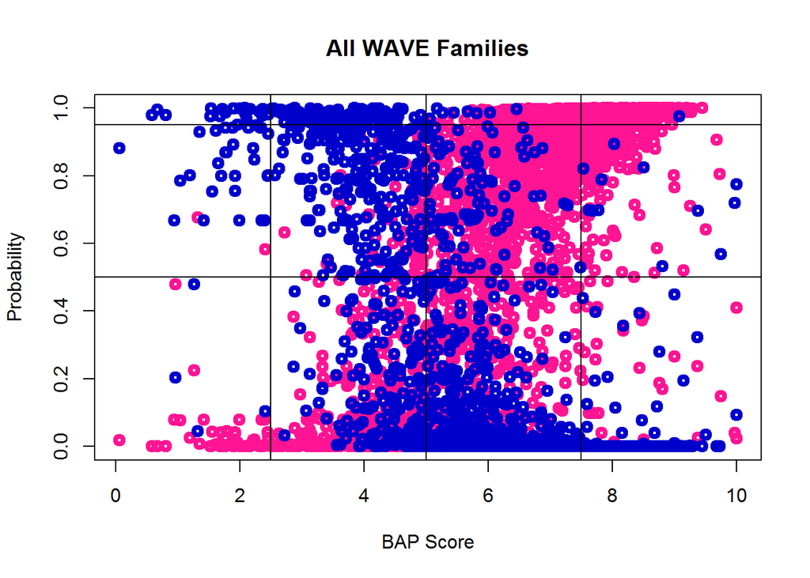

### All Families

Perform the above calculation for All the families, including families not on the WAVE list

```
## [1] "these values should be the same. If not, then there are more than one sample per site"
```

```
## [1] 2912
```

```
## [1] 2912
```

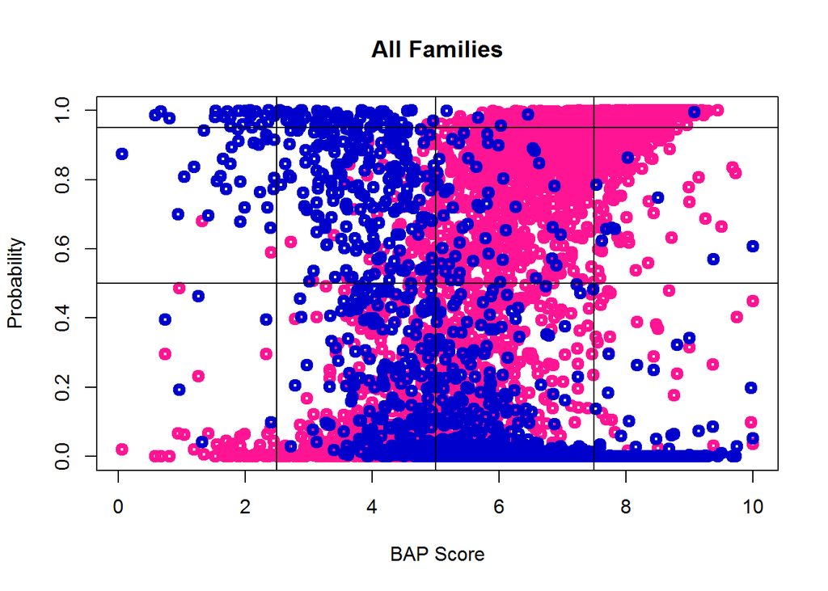

### Comparison of methods

PN The % of all the nonimpacted samples with a probability > the Cutoff  
EN The % of all the impaired or slight samples inaccurately identified as nonimpacted by this method  
ENI The % of all the impaired samples (allowing errors in slight) inaccurately identified as nonimpacted  
PI The % of all the impaired samples captured with a probability > the Cutoff  
EI The % of sites identified as impaired that are actually slight or non impacted  
CutOff The sample is restricted to only records with probabilities at least of this value

| CutOff | All Families PN | All Families EN | All Families ENI | All Families PI | All Families EI | WAVE Families Only PN | WAVE Families Only EN | WAVE Families Only ENI | WAVE Families Only PI | WAVE Families Only EI |
| --- | --- | --- | --- | --- | --- | --- | --- | --- | --- | --- |
| 10 | 99 | 77.0 | 39.00 | 77.0 | 28.0 | 99 | 74.0 | 33.00 | 83 | 36.0 |
| 20 | 99 | 71.0 | 30.00 | 71.0 | 24.0 | 98 | 69.0 | 25.00 | 78 | 32.0 |
| 30 | 98 | 66.0 | 22.00 | 65.0 | 21.0 | 98 | 65.0 | 21.00 | 73 | 29.0 |
| 40 | 97 | 62.0 | 18.00 | 60.0 | 18.0 | 97 | 61.0 | 16.00 | 69 | 26.0 |
| 50 | 97 | 57.0 | 13.00 | 53.0 | 17.0 | 97 | 56.0 | 13.00 | 66 | 24.0 |
| 60 | 96 | 51.0 | 8.70 | 48.0 | 15.0 | 95 | 51.0 | 8.70 | 61 | 22.0 |
| 70 | 94 | 46.0 | 5.60 | 42.0 | 12.0 | 94 | 45.0 | 6.00 | 54 | 18.0 |
| 80 | 92 | 37.0 | 3.30 | 33.0 | 9.4 | 92 | 37.0 | 3.90 | 44 | 14.0 |
| 90 | 85 | 25.0 | 1.70 | 23.0 | 7.1 | 84 | 24.0 | 1.90 | 33 | 9.2 |
| 95 | 76 | 16.0 | 0.52 | 15.0 | 5.4 | 74 | 14.0 | 0.35 | 20 | 7.3 |
| 96 | 72 | 13.0 | 0.35 | 13.0 | 5.1 | 70 | 12.0 | 0.18 | 17 | 8.7 |
| 97 | 68 | 11.0 | 0.00 | 11.0 | 6.1 | 66 | 10.0 | 0.00 | 14 | 9.1 |
| 98 | 61 | 8.1 | 0.00 | 8.2 | 6.0 | 59 | 7.1 | 0.00 | 11 | 10.0 |

Comparison Plot

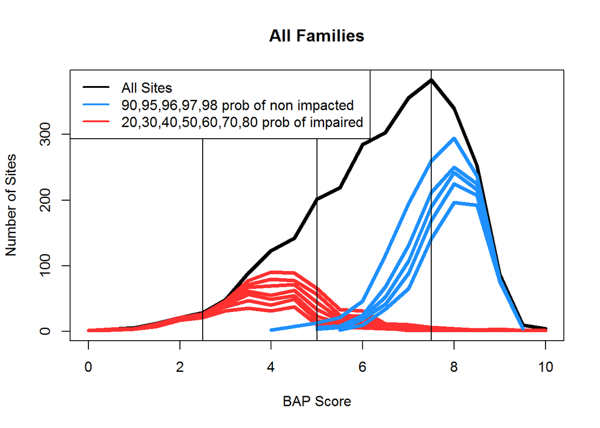

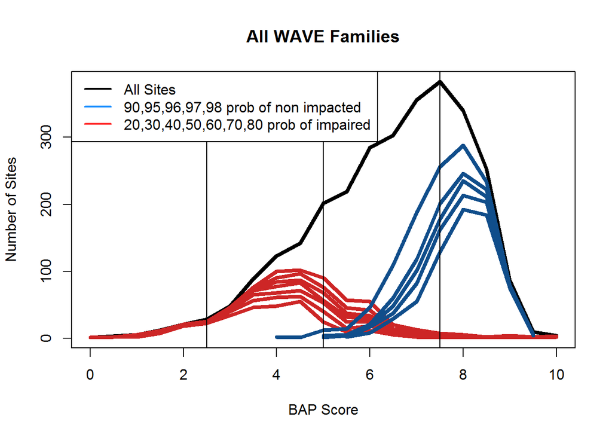

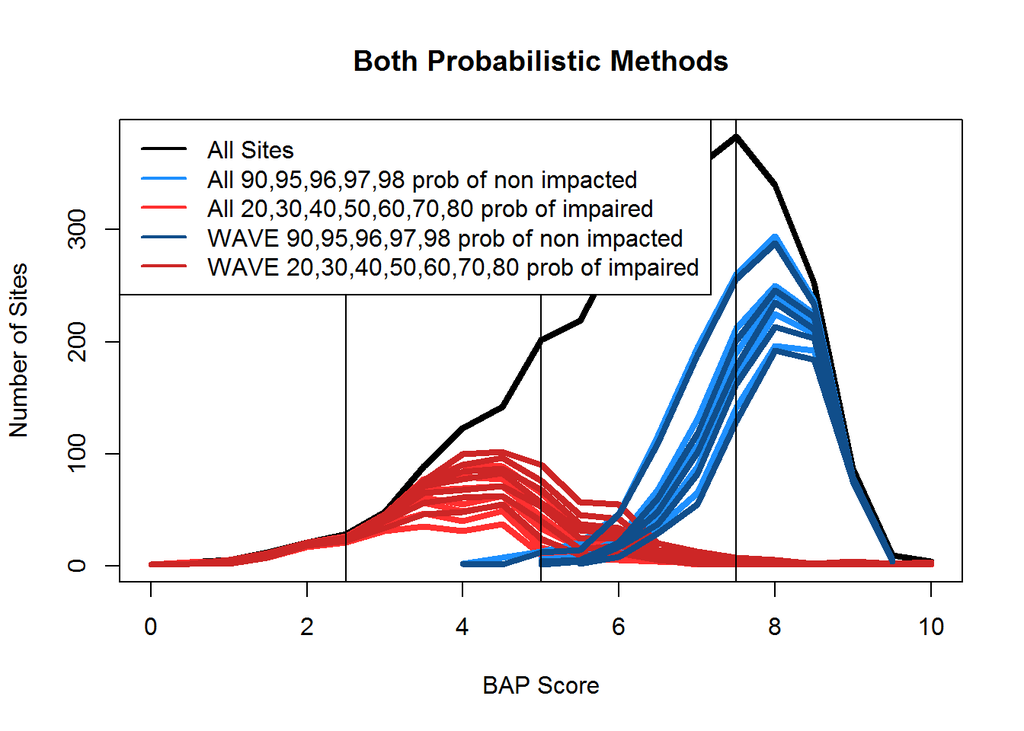

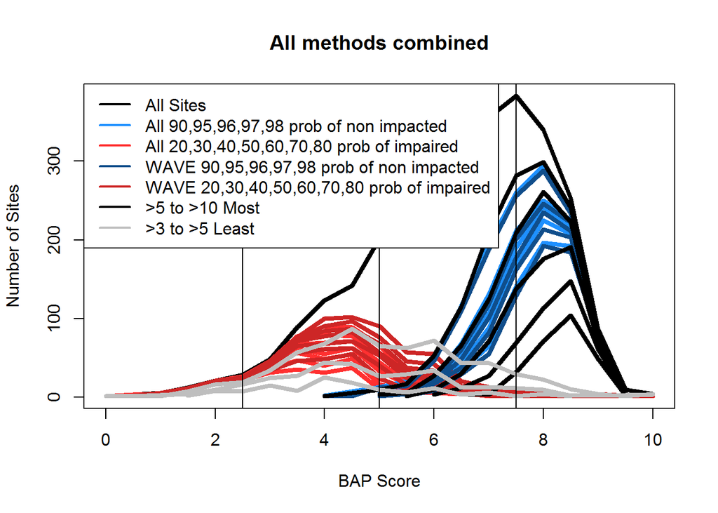

## Conclusions thus far

This graph shows that the probabilities calcualted by using only WAVE families capture slightly fewer Non-Impacted sites and slightly more impaired sites.  
The probability based method doesn’t fare particularly better at capturing Non Impacted sites compared to the Most Wanted method. Since the latter is easier for the public to understand, I feel it’s worth sticking with this method.

The opposite is true for impaired sites. The probability based method is better at capturing impaired sites with a lower error rate. Since this method is used to red flag sites for professional investigation, I feel it’s ok to use this method even though it may be more confusing to the public.

I feel these are the best methods for WAVE moving forward:  
6 or more Most Wanteds will capture 76% of the Non-Impacted sites and 0% of impaired sites. It’s important to understand that it will erroneously identify slightly impacted sites as non-impacted. We have decided that’s an acceptable error since the regulatory response is only triggered by the impaired category. We should consider relabeling this result as Non-Impaired rather than Non-Impacted.

Next we would like to examine using the Baes calculation on pair frequencies.